# Bellabeat Case Study

How Consumers Use Fitness Tracking Data

Mary A.Trankel

2026-05-06

# 1 Introduction & Business Context

[*Bellabeat*](https://bellabeat.com/) is a wellness technology company that develops data-driven products to support women’s health across activity, sleep, and lifestyle domains. As the wearable technology market becomes increasingly competitive and saturated, sustained engagement depends not only on feature parity but on how effectively products translate behavioral data into meaningful, actionable insights for users.

This case study analyzes publicly available *Fitbit* fitness tracker data to explore patterns in user activity, sleep behavior, and engagement over time. The purpose of the analysis is to identify consistent usage patterns, behavioral gaps, and engagement opportunities that could inform *Bellabeat’s* marketing strategy and product positioning.

## 1.1 Business task & key questions

The analytical approach in this project reflects an applied research and decision‑support mindset focused on *reproducibility* and *sound data practices*. Raw source data are preserved, all transformations are documented, and analytical decisions are grounded in practical evaluation principles rather than purely exploratory or theoretical modeling. This workflow mirrors how data analysts operate in applied industry contexts where transparency, reliability, and interpretability are critical for stakeholder trust and downstream decision‑making.

Drawing on over a decade of experience conducting mixed‑methods research and evaluation in real‑world settings, this analysis emphasizes insights that are both empirically defensible and operationally useful. While the dataset represents *Fitbit* users rather than *Bellabeat* customers directly, the observed behavioral patterns offer a strong empirical basis for refining engagement strategies and guiding future hypothesis‑driven analysis.

## 1.2 Stakeholders

- **Urška Sršen**, Co-Founder and Chief Creative Officer of *Bellabeat*; believes that analyzing smart device fitness data could help unlock new growth opportunities for the company.
- **Sando Mur**, Mathematician and *Bellabeat* Co-Founder; key member of the Executive Team.
- **Marketing Analytics Team**, a team of data analysts responsible for collecting, analyzing and reporting data that helps guide *Bellabeat’s* marketing strategies.

## 1.3 Focus of this analysis

[*Bellabeat’s **Time***](https://bellabeat.com/shop) device was selected for this analysis. *Time* is a [*smart watch*](https://bellabeat.com/product/time/) with an app that provides health data related to the user’s activity level, sleep patterns, and other mindful habits. The app data is intended to help users understand their current habits in order to make healthy decisions. The tagline indicates that **Time** will effortlessly blend into your everyday as a luxury hybrid wellness watch, suitable for any occasion.

**Benefits** of the *Time* smart watch with included app:

- Optimized for women’s health
- Calculates Wellness score
- Monitors activity and sleep
- Tracks menstrual cycle, meditation, and hydration
- Gives insights into your health and lifestyle with guidance on how to improve them
- Lightweight, safe for skin, and hypoallergenic

# 2 Key Questions

1. What are some trends in [smart device](https://en.wikipedia.org/wiki/Smart_device) usage?
2. How could these trends apply to *Bellabeat* customers?
3. How could these trends help influence *Bellabeat* **marketing strategy** to improve engagement by customers?

# 3 Data Sources & Preparation

## 3.2 Limitations of the data

One limitation of this dataset is that not all users contributed data to all tables.

# 4 Data Cleaning & Processing

All data cleaning and preparation steps are documented in **~project/scripts**. Scripts should be executed in the numbered sequence represented by the .R file names.

## 4.1 Data workflow & reproducibility

- Raw data is stored in **~project/data/raw**
- All cleaning processes are scripted
- Processed datasets are written to **~project/data/processed**
- Analysis was performed on processed data only

## 4.2 Data cleaning decisions

- Removed duplicate records
- Filtered invalid or zero-activity days
- Standardized date formats
- Checked for missing values

# 5 Analysis & Key Findings

Daily data was examined to establish baseline engagement with the *Time* device. This included: - Daily activity levels (steps per day) - Active vs sedentary time

## 5.1 Specific guiding questions:

- When during the day do users engage most with their wearable device?
- How consistent is device usage across days and users?
- Where are the largest gaps in activity or engagement?
- How can Bellabeat **Time** better support daily routines?

## 5.2 Daily activity levels

A primary goal was to focus on intra-day activity rather than simple daily totals. Here I emphasize time-of-day behavior to identify patterns that can inform *Bellabeat* marketing strategies for the **Time** device.

The plot below was generated to display *when users actually engage* with their device during a typical day.

This approach helps answer the following specific questions:

✔ What are the trends in smart device usage?  
✔ When during the day do users actually engage with their device?

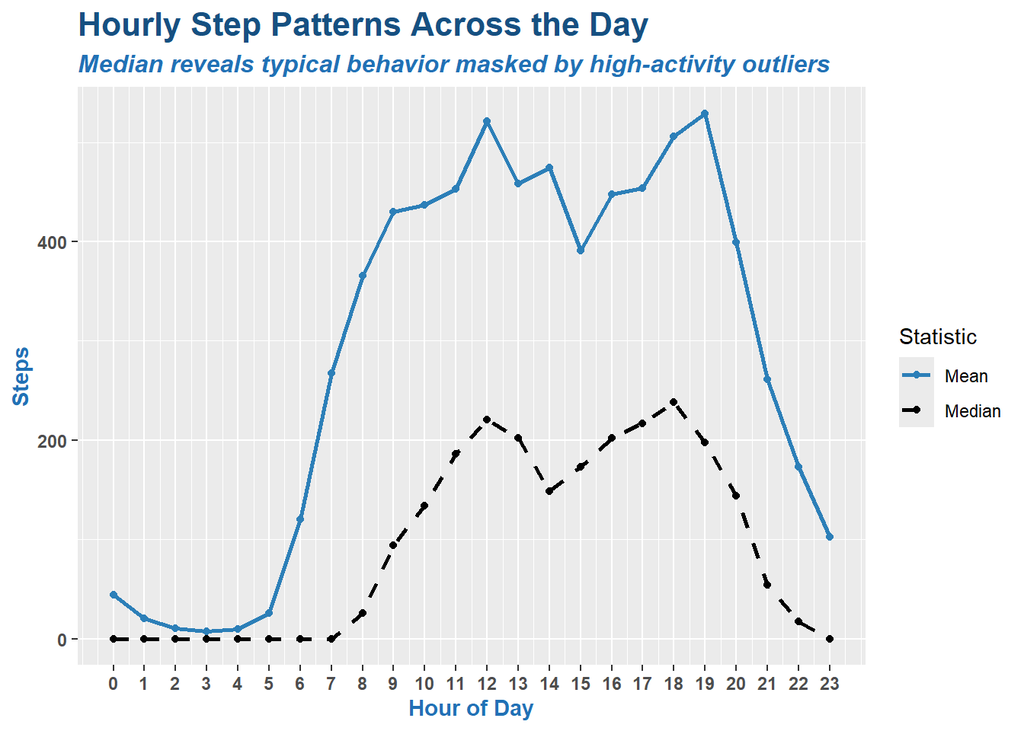

### 5.2.1 Behavioral insights

Users are most active during consistent daytime windows, with noticeable peaks that are clear for two different types of users. **Mean** step counts are influenced by a small number of highly active users. I have added the **median** step count to this graphic because it reveals a stable, routine-driven activity pattern that is more typical for the majority of users.

These patterns help answer the original business question: *When do users actually engage with their device during a typical day?*

### 5.2.2 Marketing implications

- The observed patterns indicate that most users engage with their wearable device as part of predictable daily routines, rather than sporadic bursts of extreme activity.
- *Bellabeat* should emphasize *habit reinforcement* rather than *performance optimization*.
- Messaging, notifications, and content should align with morning and early evening routines in order to reinforce consistency, rather than intensity.

After identifying when users are active, we examine how intensely they move throughout those periods.

## 5.3 Activity intensity by time of day

With the next chart we address the following business questions:

✔ How could usage trends apply to Bellabeat customers?  
✔ Where does the device deliver the most value during the day?

This addresses the question: *When does Bellabeat Time deliver the most behavioral value?*

Here we can see that *smart watch* users are not primarily using the device for high intensity training. Users primarily use the device to support moderate, sustainable activity. Note that this chart presents information about *median* as well as *mean*. As a result, we can see that this dataset is skewed by the higher activity performed by a small portion of users in this sample. So in this case the *median* is a *more accurate reflection of the true average* for the majority of users.

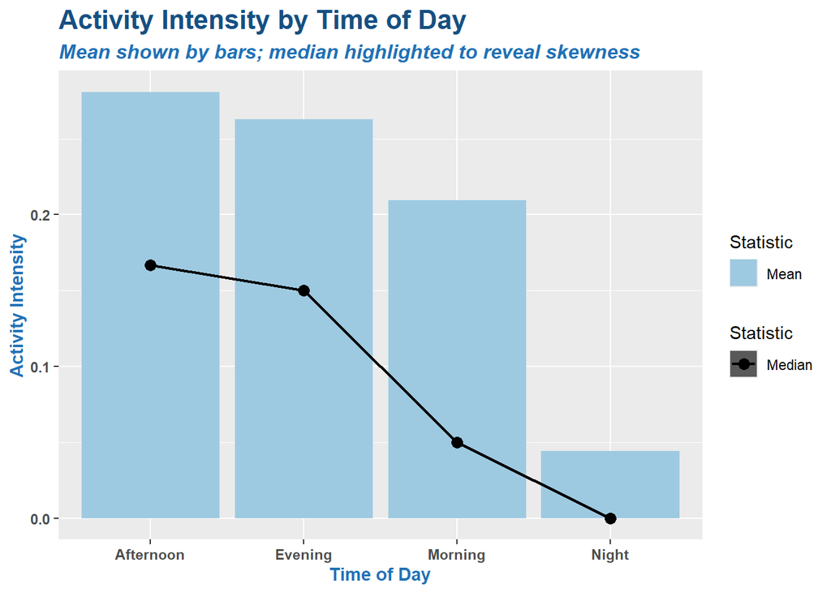

### 5.3.2 Marketing implications

Marketing should avoid positioning *Bellabeat Time* as a fitness tracker for “elite” or “high performance” users. Instead, it should frame intensity feedback as guidance for *balance, energy management, and overall well being*. This finding also supports the idea that wellness-focused features such as sleep, stress reduction, and mindfulness are equally valuable with movement tracking.

Next, we assess whether these patterns hold consistently across different types of days within the week.

## 5.4 Routine stability patterns

This section examines whether daily engagement rhythms persist across weekdays and weekends. By doing this we can address the following business questions:

✔ How consistent is device usage?  
✔ How predictable are engagement patterns?

The chart below helps us understand whether users are wearing and engaging with their device consistently, or only opportunistically. This supports *Bellabeat’s* holistic wellness positioning - that users are not optimizing one behavior at the expense of another; rather, they are balancing both.

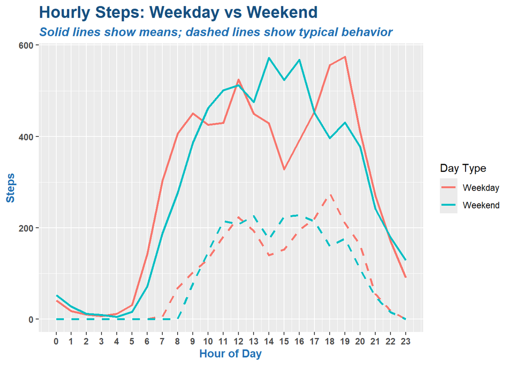

### 5.4.2 Marketing implications

Bellabeat can credibly position its product as supporting sustainable wellness, not “burnout fitness.” Campaigns can emphasize balance, long term health, and self awareness rather than maximizing metrics. This is especially aligned with Bellabeat’s female focused branding and lifestyle emphasis.

Beyond activity timing and consistency, we now explore how engagement relates to recovery.

## 5.5 Sleep patterns

I chose to recreate daily sleep metrics directly from minute-level sleep data instead of relying on pre-aggregated tables. This provided more control over assumptions such as *what constitutes a nap*. In the chart below we examine: - Average sleep duration - Relationship between activity and sleep

Next we explore the consistency of tracker usage for activity level vs. sleep patterns. In doing so we address the following business questions:

✔ How can Bellabeat influence engagement?  
✔ What actionable user groups exist?

### 5.5.1 Daily steps vs. sleep duration

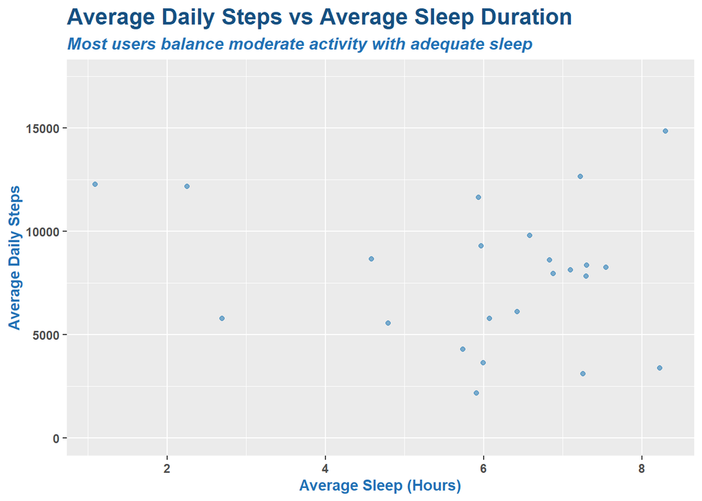

### 5.5.3 Marketing implication

*Bellabeat* can design differentiated strategies: - Encourage Low Engagement users with habit building prompts - Reinforce Moderate users’ consistency - Offer optional depth for High Engagement users without overwhelming others

This segmentation supports personalized marketing without requiring demographic data.

Finally, we synthesize these behaviors into actionable user segments.

## 5.6 User engagement segments

The boxplot below addresses the question: *Who are our users, in behavioral terms we can act on?*

Specific business questions addressed here include:

✔ How can Bellabeat influence engagement?  
✔ What actionable user groups exist?

The dark horizontal line inside each segment box is the *median* for users in that activity segment. It represents the most typical user in each segment in terms of median daily step count. It is not influenced by very high or very low outliers, so it is particularly appropriate for this type of data, which is skewed by a small number of power users.

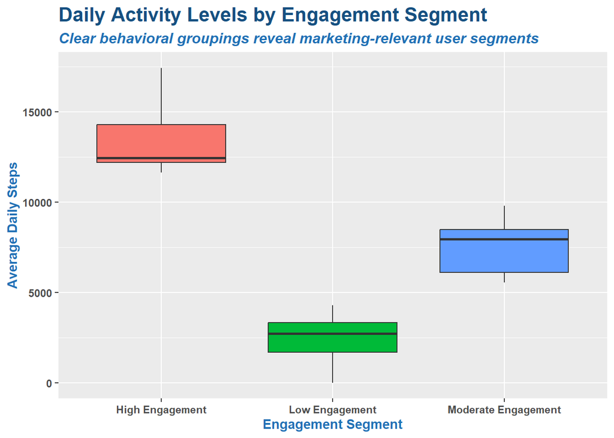

### 5.6.1 Behavioral insights

Users naturally fall into clear segments (Low, Moderate, and High engagement), with meaningful differences in step behavior. Why this matters for Bellabeat *Time*: Not all users need the same messaging, features, or nudges. A single “one size fits all” engagement strategy will underperform.

### 5.6.2 Marketing implications

*Bellabeat* can design differentiated strategies:

- **Encourage *Low Engagement* users** with habit-building prompts
- **Reinforce *Moderate* users** regarding consistency
- **Offer optional depth for *High Engagement* users** without overwhelming others

This segmentation supports personalized marketing without requiring demographic data.

# 6 Summary & Recommendations

## 6.1 Summary

Taken together, these findings point toward marketing strategies that prioritize consistency, personalization, and balance rather than performance optimization. The five figures presented here support the following conclusions:

1. Smart device usage is routine-driven, not extreme, for the majority of users.
2. Users value *balance* in their activity over optimization (extreme activity).
3. Engagement is consistent - but heterogeneous within low, moderate and high engagement sectors.
4. *Bellabeat **Time*** aligns naturally with sustainable wellness features of importance to smart watch users.
5. Targeted marketing strategies could improve customer engagement without adding product features.

Note that additional descriptive charts are included in the Appendix.

## 6.2 Recommendations

It is possible that *Time* users are not initially aware of all possibilities available with the *Time* device, since customers may have started their usage with a simple strategy like “counting steps”. It could be helpful to encourage users to explore additional options already available with the *Time* device.

Based on this summary of results, I would recommend the following marketing strategies for *Bellabeat **Time*** customers. Care should be taken to target these approaches appropriately for each of the three segments of users:

- Low Engagement
- Moderate Engagement
- High Engagement

✔ Recommendation 1: Feature Messaging  
✔ Recommendation 2: Engagement Nudges  
✔ Recommendation 3: Education or Content Strategy

# 7 Limitations & Next Steps

This sample represents *smart device* users, and the analysis extrapolates these results to mirror *Bellabeat* customers of the *Time* smart watch.

The dataset was not collected by *FitBit* directly. It was generated through a distributed survey administered via [Amazon Mechanical Turk (MTurk)](https://rstudio-pubs-static.s3.amazonaws.com/789716_ca2be6de341f44c0b9e31695921e857f.html). Participants voluntarily submitted their FitBit tracking data for research use.

## 7.1 Key implications:

- Participants were self-selected (not a random sample).
- We cannot assume that all participants were women.
- Data reflects users that were comfortable sharing their personal health data.
- Usage behavior may differ from the general population of wearable device users.
- No demographic information is available, although this segmentation of users supports personalized marketing approaches without the necessity of considering demographic data.
- Device usage spans multiple FitBit devices, not a single model https://mikanzuka.github.io/Data-Analysis-with-R/
- This analysis provides observational data only, and results cannot be assumed to justify causal conclusions.
  - The sample size is too small for a statistical analysis of causal probability.
  - This dataset cannot be considered a random sample of *smart device* users.

## 7.2 Next steps

If feasible, Bellabeat could consider one or both of the following options:

- Gather similar data on existing *Bellabeat* customers who purchased the *Time* device to compare how closely they match the behavior patterns of users in this data sample.
- Gather survey data from *Bellabeat **Time*** device users to collect additional data about:
  - existing features they like, including “how” and “why” these use these features
  - new features they may wish to see in the future. This information could help *Bellabeat* plan future enhancements that will help the company remain competitive in the marketplace.

# 8 APPENDICES

The appendices provide supporting visualizations and summary tables that supplement the main analysis without interrupting the narrative flow of the report. These materials offer additional methodological transparency, demonstrate the robustness of feature engineering decisions, and illustrate exploratory patterns that inform—but do not drive—the primary business conclusions presented above.

## 8.1 APPENDIX A: Supporting Distributions

**Appendix** A contains supplemental plots that describe the distribution and shape of key activity and sleep variables. These figures support analytic decisions made in the main report, such as the use of *medians* in addition to *means*. These plots also help contextualize user behavior variability across the dataset.

**Purpose:** *Show data shape and skew that justify addition of **medians**.*

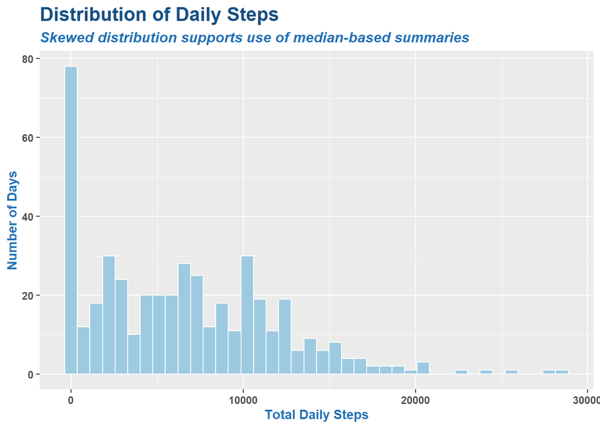

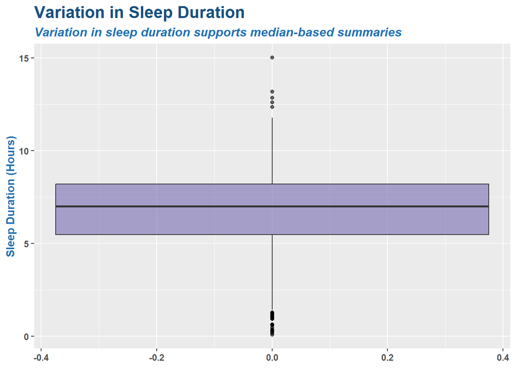

## 8.2 APPENDIX B: User Level Summary Tables

**Appendix B** presents compact summary tables derived from user level aggregated datasets. These tables demonstrate feature engineering logic, summarize typical user behavior across the observation period, and provide quantitative support for the engagement segments referenced in the main analysis.

**Purpose:** *Demonstrate segmentation logic and feature engineering*

User Engagement Segment Summary

| activity_segment | users_in_segment | median_daily_steps | median_sleep_hours | median_active_hours |
| --- | --- | --- | --- | --- |
| High Engagement | 6 | 12450.024 | 5.934667 | 23.56250 |
| Low Engagement | 14 | 2717.708 | 5.991667 | 23.56250 |
| Moderate Engagement | 15 | 7943.400 | 6.582258 | 23.54839 |

Daily Activity Summary Across Users

| total_users | median_avg_daily_steps | iqr_avg_daily_steps | median_step_variability |
| --- | --- | --- | --- |
| 35 | 6103.917 | 5519.383 | 3329.626 |

Hourly Engagement and Device Wear Summary

| total_users | median_active_hours_per_day | median_avg_hourly_steps | median_avg_intensity |
| --- | --- | --- | --- |
| 34 | 23.5625 | 251.0017 | 0.1694481 |

## 8.3 APPENDIX C: Exploratory Data & Visualizations

**Appendix C** includes exploratory visualizations that highlight secondary behavioral patterns related to timing, intensity, and sleep behavior. These views offer additional depth and nuance, but were not required to answer the primary business questions guiding this analysis.

### 8.3.1 Evening Activity Preference

**Purpose:** This visualization illustrates the distribution of evening focused activity across users, and supports conclusions about *routine-based* versus *time-concentrated* engagement. While not central to the main business questions, this histogram provides additional insight into how users allocate activity within their day.

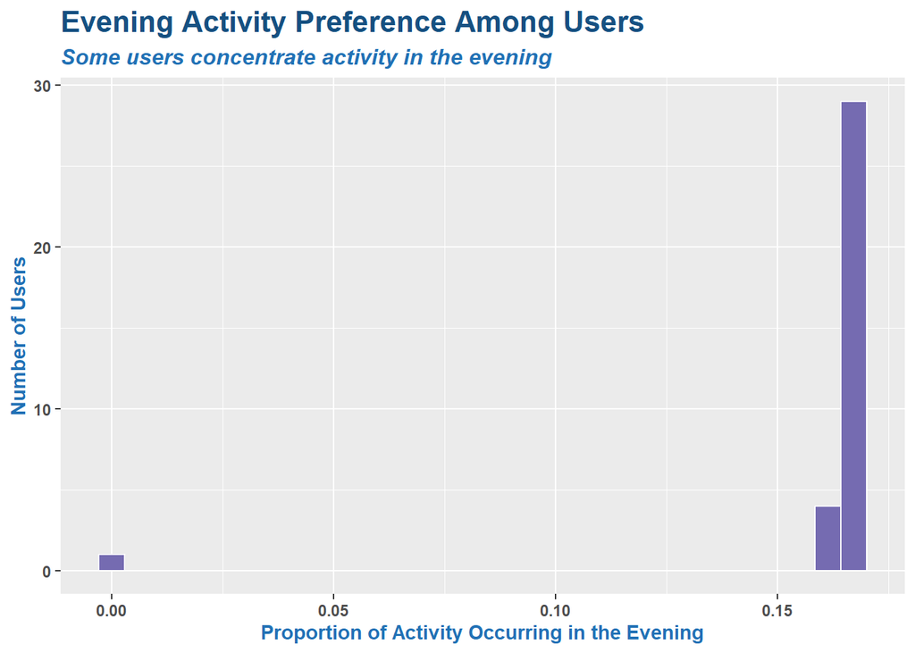

### 8.3.2 Activity Intensity vs. Active Hours

**Purpose:** This plot explores the relationship between activity intensity and total daily engagement time, highlighting the observation that extended device use does not require high intensity activity. The figure reinforces the positioning of Bellabeat Time as a wellness oriented device rather than a performance training tool.

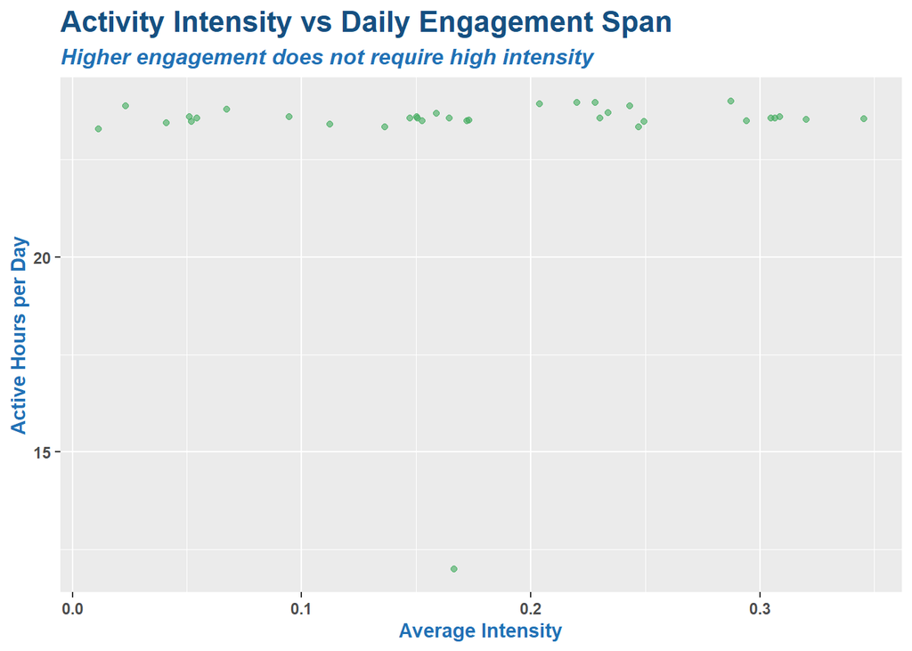

### 8.3.3 Sleep Duration Patterns

**Purpose:** This plot provides a nuanced view of sleep behavior by distinguishing shorter daytime rest periods from overnight sleep. While not essential to the primary analysis, this illustrates the flexibility of minute-level data for future hypothesis analysis related to recovery and rest patterns.

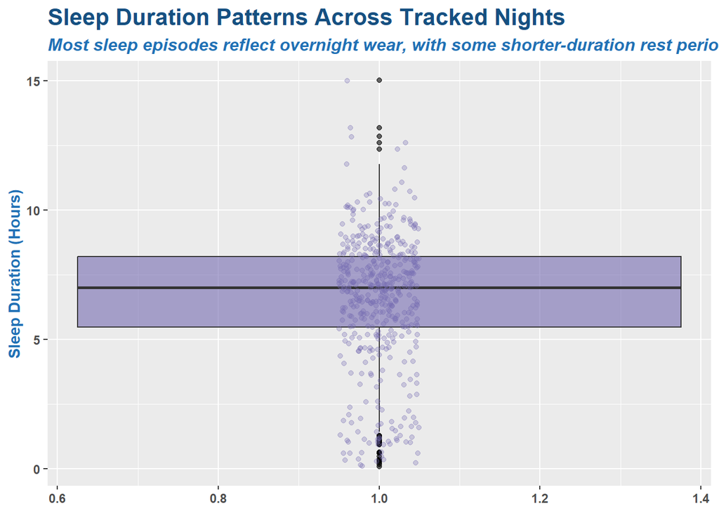

## 8.4 APPENDIX D: Shared Files

- [Bellabeat Time Case Study](https://marytrankel.com/work-samples/analytics/bellabeat_analysis.html) – **HTML report** generated by markdown file
- [Bellabeat Time Case Study](https://marytrankel.com/work-samples/analytics/Bellabeat-Time-Case-Study-MATrankel.docx) – **Word report** with technical and methodological details
  - *Full analytical report with data preparation, assumptions, and appendix materials*
- [Bellabeat Time Case Study](https://marytrankel.com/work-samples/analytics/Bellabeat-Time-Case-Study-MATrankel.pptx) – **PPT stakeholder presentation** with Executive Summary
  - Slide deck summarizing key findings, insights, and recommendations.
- [Reproducible Analysis Files](https://www.kaggle.com/datasets/marytrankel/bellabeat-analysis-matrankel) – **R scripts & markdown files** (*Kaggle* Notebook)
  - 01_import.R
  - 02_clean.R
  - 03_metrics.R
  - Primary R Markdown File – Source notebook used to generate the analysis
- [GitHub](https://github.com/ma-trankel/bellabeat-analysis.git) – Repository containing R programming scripts and cleaned dataset CSV files